# MGTA 495: Analytics Assignment 4

## Sagemaker Classification

Perform a classification task on the dataset explored in the previous assignment.  
Using the features given, you will train a XGBoost decision tree model to predict a given person's salary (the `WAGP` column)

#### Tasks:

- Perform EDA on the given dataset
- Save preprocessed datasets to Amazon S3
- Use the Amazon Sagemaker platform to train an XGBoost model
- Evaluate the model using both a Batch-Transform job and a Real Time Predictor
- Perform hyperparameter tuning on the XGBoost model
- Submit
  - Completed Sagemaker notebook with correct code and outputs
    - Also submit the exported HTML
  - Writeup
    - As we have given you a lot of code this time, we expect you to explain what every step in the notebook does, in detail
  - Screenshots
    - A completed Batch Transform job in SageMaker console
    - Empty Endpoint list in SageMaker console, after deleting the Endpoint
    - (Optional) A completed hyperparameter tuning job in SageMaker console.

#### Due: Tuesday, 03/10/2020 at 11:59pm Pacific Time

Remember: when in doubt, read the documentation first. It's always helpful to search for the class that you're trying to work with, e.g. pyspark.sql.DataFrame.

Pandas API documentation: https://pandas.pydata.org/pandas-docs/stable/reference/index.html

Amazon Sagemaker API documentation: https://sagemaker.readthedocs.io/en/stable/

Amazon Sagemaker Tutorials: https://docs.aws.amazon.com/sagemaker/latest/dg/gs.html

## 0) Startup

Expected outputs: None

### 0.a) Import packages

```python
import boto3, os, sagemaker
from sagemaker import get_execution_role
```

### 0.b) Get Amazon IAM execution role and instance region

```python
# Define IAM role- this will be necessary when defining your model
iam_role = get_execution_role()

# set the region of the instance and get a reference to the client
my_region = boto3.Session().region_name

# sagemaker session handle
sm_session = sagemaker.session.Session(boto3.Session())

print("Success - the SageMaker instance is in the " + my_region + " region")
```

```
Success - the SageMaker instance is in the us-west-2 region
```

## 1) Load and examine data

Expected outputs:

1. Evidence of data inspection. Anything to show that you have properly examined the data.
2. for **1.d)**, the first 5 rows of the merged dataframe with only selected columns.
3. for **1.e)**, the correlation values between features from 1.d) and WAGP, and summary statistics of the WAGP column.

### 1.a) Load CSV data from s3, and the dictionary pickle from local

Upload `person_records_A.csv` and `person_records_B.csv` to S3, into a bucket and folder of your choice. Read the data files as Pandas dataframes using their S3 URLs. Read the pickle file by uploading it to the notebook container and using `pickle.load()`.

```python
import pandas as pd
import pickle

bucket = "mgta495-hw3/"
folder = "data/"

df_A = pd.read_csv("s3://{}{}person_records_A.csv".format(bucket, folder))
df_B = pd.read_csv("s3://{}{}person_records_B.csv".format(bucket, folder))

pr_ddict = pickle.load(open("person_ddict.pickle", "rb"))
```

### 1.b) Examine data schema and counts

```python
# YOUR CODE HERE
df_A.dtypes
```

```
SERIALNO      int64
SPORDER       int64
PUMA          int64
ST            int64
ADJINC        int64
AGEP          int64
CIT           int64
CITWP       float64
COW         float64
DDRS        float64
DEAR          int64
DEYE          int64
DOUT        float64
DPHY        float64
DRAT        float64
DRATX       float64
DREM        float64
ENG         float64
FER         float64
GCL         float64
GCM         float64
GCR         float64
HINS1         int64
HINS2         int64
HINS3         int64
HINS4         int64
HINS5         int64
HINS6         int64
HINS7         int64
INTP        float64
             ...
PAOC        float64
PERNP       float64
PINCP       float64
POBP          int64
POVPIP      float64
POWPUMA     float64
POWSP       float64
PRIVCOV       int64
PUBCOV        int64
QTRBIR        int64
RAC1P         int64
RAC2P         int64
RAC3P         int64
RACAIAN       int64
RACASN        int64
RACBLK        int64
RACNH         int64
RACNUM        int64
RACPI         int64
RACSOR        int64
RACWHT        int64
RC            int64
SFN         float64
SFR         float64
SOCP         object
VPS         float64
WAOB          int64
FHINS3C     float64
FHINS4C     float64
FHINS5C     float64
Length: 127, dtype: object
```

```python
df_A.count()
```

```
SERIALNO    1613672
SPORDER     1613672
PUMA        1613672
ST          1613672
ADJINC      1613672
AGEP        1613672
CIT         1613672
CITWP        109899
COW          944421
DDRS        1528219
DEAR        1613672
DEYE        1613672
DOUT        1332197
DPHY        1528219
DRAT          21094
DRATX        136387
DREM        1528219
ENG          306114
FER          361749
GCL         1029173
GCM           14384
GCR           37211
HINS1       1613672
HINS2       1613672
HINS3       1613672
HINS4       1613672
HINS5       1613672
HINS6       1613672
HINS7       1613672
INTP        1332197
             ...
PAOC         648439
PERNP       1311329
PINCP       1332197
POBP        1613672
POVPIP      1547274
POWPUMA      705112
POWSP        705112
PRIVCOV     1613672
PUBCOV      1613672
QTRBIR      1613672
RAC1P       1613672
RAC2P       1613672
RAC3P       1613672
RACAIAN     1613672
RACASN      1613672
RACBLK      1613672
RACNH       1613672
RACNUM      1613672
RACPI       1613672
RACSOR      1613672
RACWHT      1613672
RC          1613672
SFN           55034
SFR           55034
SOCP         944421
VPS          117477
WAOB        1613672
FHINS3C      314619
FHINS4C      287480
FHINS5C       50014
Length: 127, dtype: int64
```

```python
df_B.count()
```

```
SERIALNO    1519123
SPORDER     1519123
PUMA        1519123
ST          1519123
ADJINC      1519123
AGEP        1519123
CIT         1519123
CITWP         73355
COW          899801
DDRS        1436957
DEAR        1519123
DEYE        1519123
DOUT        1249845
DPHY        1436957
DRAT          20878
DRATX        132983
DREM        1436957
ENG          227596
FER          339459
GCL          965956
GCM           13509
GCR           32421
HINS1       1519123
HINS2       1519123
HINS3       1519123
HINS4       1519123
HINS5       1519123
HINS6       1519123
HINS7       1519123
INTP        1249845
             ...
PAOC         607540
PERNP       1230190
PINCP       1249845
POBP        1519123
POVPIP      1454706
POWPUMA      676751
POWSP        676751
PRIVCOV     1519123
PUBCOV      1519123
QTRBIR      1519123
RAC1P       1519123
RAC2P       1519123
RAC3P       1519123
RACAIAN     1519123
RACASN      1519123
RACBLK      1519123
RACNH       1519123
RACNUM      1519123
RACPI       1519123
RACSOR      1519123
RACWHT      1519123
RC          1519123
SFN           46136
SFR           46136
SOCP         899801
VPS          114419
WAOB        1519123
FHINS3C      296151
FHINS4C      249886
FHINS5C       50562
Length: 127, dtype: int64
```

```python
df_A.describe()
```

|  | SERIALNO | SPORDER | PUMA | ST | ADJINC | AGEP | CIT | CITWP | COW | DDRS | ... | RACSOR | RACWHT | RC | SFN | SFR | VPS | WAOB | FHINS3C | FHINS4C | FHINS5C |
| --- | --- | --- | --- | --- | --- | --- | --- | --- | --- | --- | --- | --- | --- | --- | --- | --- | --- | --- | --- | --- | --- |
| count | 1.613672e+06 | 1.613672e+06 | 1.613672e+06 | 1.613672e+06 | 1613672.0 | 1.613672e+06 | 1.613672e+06 | 109899.000000 | 944421.000000 | 1.528219e+06 | ... | 1.613672e+06 | 1.613672e+06 | 1.613672e+06 | 55034.000000 | 55034.000000 | 117477.000000 | 1.613672e+06 | 314619.000000 | 287480.000000 | 50014.000000 |
| mean | 7.462211e+05 | 2.110607e+00 | 3.075301e+03 | 1.391044e+01 | 1007549.0 | 4.051317e+01 | 1.473806e+00 | 1995.048399 | 2.192383 | 1.963660e+00 | ... | 4.773213e-02 | 7.712038e-01 | 2.079152e-01 | 1.019951 | 3.584729 | 7.278216 | 1.400552e+00 | 0.061694 | 0.092911 | 0.006618 |
| std | 4.309347e+05 | 1.368338e+00 | 2.994329e+03 | 7.856692e+00 | 0.0 | 2.346892e+01 | 1.190743e+00 | 14.632059 | 1.985641 | 1.871340e-01 | ... | 2.131990e-01 | 4.200579e-01 | 4.058160e-01 | 0.144185 | 1.560391 | 3.796395 | 1.061084e+00 | 0.240599 | 0.290308 | 0.081083 |
| min | 1.000000e+00 | 1.000000e+00 | 1.000000e+02 | 1.000000e+00 | 1007549.0 | 0.000000e+00 | 1.000000e+00 | 1928.000000 | 1.000000 | 1.000000e+00 | ... | 0.000000e+00 | 0.000000e+00 | 0.000000e+00 | 1.000000 | 1.000000 | 1.000000 | 1.000000e+00 | 0.000000 | 0.000000 | 0.000000 |
| 25% | 3.723675e+05 | 1.000000e+00 | 8.020000e+02 | 6.000000e+00 | 1007549.0 | 2.000000e+01 | 1.000000e+00 | 1987.000000 | 1.000000 | 2.000000e+00 | ... | 0.000000e+00 | 1.000000e+00 | 0.000000e+00 | 1.000000 | 3.000000 | 5.000000 | 1.000000e+00 | 0.000000 | 0.000000 | 0.000000 |
| 50% | 7.457795e+05 | 2.000000e+00 | 2.000000e+03 | 1.200000e+01 | 1007549.0 | 4.100000e+01 | 1.000000e+00 | 1999.000000 | 1.000000 | 2.000000e+00 | ... | 0.000000e+00 | 1.000000e+00 | 0.000000e+00 | 1.000000 | 3.000000 | 6.000000 | 1.000000e+00 | 0.000000 | 0.000000 | 0.000000 |
| 75% | 1.119428e+06 | 3.000000e+00 | 3.762000e+03 | 2.100000e+01 | 1007549.0 | 5.900000e+01 | 1.000000e+00 | 2007.000000 | 3.000000 | 2.000000e+00 | ... | 0.000000e+00 | 1.000000e+00 | 0.000000e+00 | 1.000000 | 5.000000 | 11.000000 | 1.000000e+00 | 0.000000 | 0.000000 | 0.000000 |
| max | 1.492843e+06 | 2.000000e+01 | 1.270400e+04 | 2.800000e+01 | 1007549.0 | 9.500000e+01 | 5.000000e+00 | 2013.000000 | 9.000000 | 2.000000e+00 | ... | 1.000000e+00 | 1.000000e+00 | 1.000000e+00 | 3.000000 | 6.000000 | 15.000000 | 8.000000e+00 | 1.000000 | 1.000000 | 1.000000 |

8 rows × 125 columns

```python
df_B.describe()
```

|  | SERIALNO | SPORDER | PUMA | ST | ADJINC | AGEP | CIT | CITWP | COW | DDRS | ... | RACSOR | RACWHT | RC | SFN | SFR | VPS | WAOB | FHINS3C | FHINS4C | FHINS5C |
| --- | --- | --- | --- | --- | --- | --- | --- | --- | --- | --- | --- | --- | --- | --- | --- | --- | --- | --- | --- | --- | --- |
| count | 1.519123e+06 | 1.519123e+06 | 1.519123e+06 | 1.519123e+06 | 1519123.0 | 1.519123e+06 | 1.519123e+06 | 73355.000000 | 899801.000000 | 1.436957e+06 | ... | 1.519123e+06 | 1.519123e+06 | 1.519123e+06 | 46136.000000 | 46136.000000 | 114419.000000 | 1.519123e+06 | 296151.000000 | 249886.000000 | 50562.000000 |
| mean | 7.464540e+05 | 2.080306e+00 | 6.221825e+03 | 4.222795e+01 | 1007549.0 | 4.040113e+01 | 1.361277e+00 | 1994.957331 | 2.139613 | 1.963341e+00 | ... | 3.399461e-02 | 8.150841e-01 | 2.105076e-01 | 1.014349 | 3.620036 | 7.193517 | 1.314140e+00 | 0.058396 | 0.091138 | 0.005162 |
| std | 4.306558e+05 | 1.328697e+00 | 1.283412e+04 | 7.136191e+00 | 0.0 | 2.347815e+01 | 1.059994e+00 | 15.153339 | 1.913683 | 1.879225e-01 | ... | 1.812153e-01 | 3.882295e-01 | 4.076693e-01 | 0.120195 | 1.540812 | 3.812800 | 9.681315e-01 | 0.234491 | 0.287805 | 0.071662 |
| min | 6.000000e+00 | 1.000000e+00 | 1.000000e+02 | 2.900000e+01 | 1007549.0 | 0.000000e+00 | 1.000000e+00 | 1928.000000 | 1.000000 | 1.000000e+00 | ... | 0.000000e+00 | 0.000000e+00 | 0.000000e+00 | 1.000000 | 1.000000 | 1.000000 | 1.000000e+00 | 0.000000 | 0.000000 | 0.000000 |
| 25% | 3.740770e+05 | 1.000000e+00 | 9.050000e+02 | 3.600000e+01 | 1007549.0 | 2.000000e+01 | 1.000000e+00 | 1987.000000 | 1.000000 | 2.000000e+00 | ... | 0.000000e+00 | 1.000000e+00 | 0.000000e+00 | 1.000000 | 3.000000 | 5.000000 | 1.000000e+00 | 0.000000 | 0.000000 | 0.000000 |
| 50% | 7.460070e+05 | 2.000000e+00 | 2.301000e+03 | 4.200000e+01 | 1007549.0 | 4.100000e+01 | 1.000000e+00 | 1999.000000 | 1.000000 | 2.000000e+00 | ... | 0.000000e+00 | 1.000000e+00 | 0.000000e+00 | 1.000000 | 3.000000 | 6.000000 | 1.000000e+00 | 0.000000 | 0.000000 | 0.000000 |
| 75% | 1.119095e+06 | 3.000000e+00 | 4.108000e+03 | 4.800000e+01 | 1007549.0 | 5.900000e+01 | 1.000000e+00 | 2007.000000 | 3.000000 | 2.000000e+00 | ... | 0.000000e+00 | 1.000000e+00 | 0.000000e+00 | 1.000000 | 5.000000 | 11.000000 | 1.000000e+00 | 0.000000 | 0.000000 | 0.000000 |
| max | 1.492841e+06 | 2.000000e+01 | 7.030100e+04 | 5.600000e+01 | 1007549.0 | 9.500000e+01 | 5.000000e+00 | 2013.000000 | 9.000000 | 2.000000e+00 | ... | 1.000000e+00 | 1.000000e+00 | 1.000000e+00 | 3.000000 | 6.000000 | 15.000000 | 8.000000e+00 | 1.000000 | 1.000000 | 1.000000 |

8 rows × 125 columns

### 1.c) Select only the data columns

We have provided the following columns for you.

Expected outputs: None

```python
colNames = ['AGEP', 'DDRS', 'COW', 'WAGP', 'JWMNP', 'JWTR', 'MAR', 'PERNP', 'NWAV',
            'NWLA', 'NWLK', 'NWAB', 'SCHL', 'WKW', 'FOD1P', 'FOD2P']

for c in colNames:
    print(c,'\t', pr_ddict[c]['description'])
```

```
AGEP 	 Age
DDRS 	 Self-care difficulty
COW 	 Class of worker
WAGP 	 Wages or salary income past 12 months
JWMNP 	 Travel time to work
JWTR 	 Means of transportation to work
MAR 	 Marital status
PERNP 	 Total person's earnings
NWAV 	 Available for work
NWLA 	 On layoff from work
NWLK 	 Looking for work
NWAB 	 Temporary absence from work
SCHL 	 Educational attainment
WKW 	 Weeks worked during past 12 months
FOD1P 	 Recoded field of degree - first entry
FOD2P 	 Recoded field of degree - second entry
```

### 1.d) Merge dataframes and select columns

Your task:

1. Merge the two dataframes
2. Select the provided data columns

Expected output:

1. The first 5 rows of the merged dataframe with only above selected columns.

```python
df = pd.concat([df_A, df_B]).loc[:, colNames]
```

```python
df.iloc[:5]
```

|  | AGEP | DDRS | COW | WAGP | JWMNP | JWTR | MAR | PERNP | NWAV | NWLA | NWLK | NWAB | SCHL | WKW | FOD1P | FOD2P |
| --- | --- | --- | --- | --- | --- | --- | --- | --- | --- | --- | --- | --- | --- | --- | --- | --- |
| 0 | 19 | 2.0 | NaN | 0.0 | NaN | NaN | 5 | 0.0 | 5.0 | 2.0 | 2.0 | 2.0 | 19.0 | NaN | NaN | NaN |
| 1 | 55 | 2.0 | 1.0 | 52000.0 | 30.0 | 1.0 | 1 | 52000.0 | 5.0 | 3.0 | 3.0 | 3.0 | 20.0 | 1.0 | NaN | NaN |
| 2 | 56 | 2.0 | 6.0 | 0.0 | NaN | 11.0 | 1 | 99000.0 | 5.0 | 3.0 | 3.0 | 3.0 | 16.0 | 1.0 | NaN | NaN |
| 3 | 21 | 2.0 | NaN | 0.0 | NaN | NaN | 5 | 0.0 | 5.0 | 2.0 | 2.0 | 2.0 | 19.0 | NaN | NaN | NaN |
| 4 | 21 | 1.0 | NaN | 0.0 | NaN | NaN | 5 | 0.0 | 5.0 | 2.0 | 2.0 | 2.0 | 19.0 | NaN | NaN | NaN |

### 1.e) Dataframe statistics

Expected output:

1. The correlation values between 5 features from 1.d) and WAGP.
2. Summary statistics of the WAGP column.

```python
print('Correlations with WAGP')
df.loc[:, ['AGEP', 'DDRS', 'COW', 'JWMNP', 'WKW', 'WAGP']].corr(method='pearson')
```

```
Correlations with WAGP
```

|  | AGEP | DDRS | COW | JWMNP | WKW | WAGP |
| --- | --- | --- | --- | --- | --- | --- |
| AGEP | 1.000000 | -0.202793 | 0.131413 | 0.034882 | -0.167503 | -0.034028 |
| DDRS | -0.202793 | 1.000000 | -0.007077 | 0.000159 | -0.034643 | 0.100952 |
| COW | 0.131413 | -0.007077 | 1.000000 | -0.036895 | 0.004581 | -0.062779 |
| JWMNP | 0.034882 | 0.000159 | -0.036895 | 1.000000 | -0.036384 | 0.105639 |
| WKW | -0.167503 | -0.034643 | 0.004581 | -0.036384 | 1.000000 | -0.303953 |
| WAGP | -0.034028 | 0.100952 | -0.062779 | 0.105639 | -0.303953 | 1.000000 |

```python
print("WAGP statistics")
stats = df['WAGP'].describe()
stats
```

```
WAGP statistics
```

```
count    2.582042e+06
mean     2.565256e+04
std      4.736001e+04
min      0.000000e+00
25%      0.000000e+00
50%      6.000000e+03
75%      3.600000e+04
max      6.600000e+05
Name: WAGP, dtype: float64
```

## 2) Prepare data

### 2.a) Outlier Removal

Remove outlier rows based on values in the `WAGP` column. This will be an important step that impacts our model's predictive performance in the classification step below (if you're unsure why, start a Piazza discussion).

Based on the output in **1.e)**, it's clear that we need an **upper limit** to filter out significant outliers. You will have to experiment with your model to decide what you think is the ideal upper limit, but as long as you choose something reasonable (around several standard deviations above the mean), your model should achieve decent performance.

Your tasks:

1. Filter the dataframe using a calculated upper limit for WAGP

Expected Output:

1. Number of outlier rows removed from DataFrame
2. Number of rows remaining after removal
3. The upper limit above which you consider samples to be outliers.
4. Repeat **1.e)** to get summary statistics from your new dataset. Did your filtering work?

```python
# Select the number of standard deviations you want to set as the upper limit
nStddevs = 2

# find the mean and standard deviations of the WAGP column.
mean = stats['mean']
std = stats['std']

# Calculate the value of your WAGP upper limit using the calculated mean and standard deviation
val = mean + (std*nStddevs)

# Select rows using the WAGP upper limit you have just calculated
filt_df = df[df['WAGP'] < val]

# print the first 5 rows of the filtered dataframe
filt_df[:5]
```

|  | AGEP | DDRS | COW | WAGP | JWMNP | JWTR | MAR | PERNP | NWAV | NWLA | NWLK | NWAB | SCHL | WKW | FOD1P | FOD2P |
| --- | --- | --- | --- | --- | --- | --- | --- | --- | --- | --- | --- | --- | --- | --- | --- | --- |
| 0 | 19 | 2.0 | NaN | 0.0 | NaN | NaN | 5 | 0.0 | 5.0 | 2.0 | 2.0 | 2.0 | 19.0 | NaN | NaN | NaN |
| 1 | 55 | 2.0 | 1.0 | 52000.0 | 30.0 | 1.0 | 1 | 52000.0 | 5.0 | 3.0 | 3.0 | 3.0 | 20.0 | 1.0 | NaN | NaN |
| 2 | 56 | 2.0 | 6.0 | 0.0 | NaN | 11.0 | 1 | 99000.0 | 5.0 | 3.0 | 3.0 | 3.0 | 16.0 | 1.0 | NaN | NaN |
| 3 | 21 | 2.0 | NaN | 0.0 | NaN | NaN | 5 | 0.0 | 5.0 | 2.0 | 2.0 | 2.0 | 19.0 | NaN | NaN | NaN |
| 4 | 21 | 1.0 | NaN | 0.0 | NaN | NaN | 5 | 0.0 | 5.0 | 2.0 | 2.0 | 2.0 | 19.0 | NaN | NaN | NaN |

```python
print("Number of rows removed = {}".format(len(df) - len(filt_df)))

print("{} rows remaining".format(len(filt_df)))

print("Upper Limit = {}".format(val))
```

```
Number of rows removed = 626226
2506569 rows remaining
Upper Limit = 120372.57911789743
```

```python
print("WAGP statistics after filtering column")
stats = filt_df['WAGP'].describe()
stats
```

```
WAGP statistics after filtering column
```

```
count    2.506569e+06
mean     1.979075e+04
std      2.727107e+04
min      0.000000e+00
25%      0.000000e+00
50%      4.500000e+03
75%      3.300000e+04
max      1.200000e+05
Name: WAGP, dtype: float64
```

#### As we can see above, the filtering worked in changing the max value

### 2.b) Feature Selection and Cleaning

Populate `featureCols` with a subset of features from `colNames`.  
Create a new DataFrame that contains only columns `featureCols` and `labelCol`.  
Drop rows with any nulls in the selected columns.  
Print the resulting DataFrame's schema and row count, as well as the number of features you chose.

**Note**: The more features you choose, the more rows with nulls you will drop. This may be desirable if you are running into memory problems

Your tasks:

1. Select the given feature columns for training and testing the XGBoost model
2. Drop rows with any nulls

Expected Output:

1. Number of features
2. Number of rows in cleaned DataFrame
3. Cleaned DataFrame's schema

```python
featureCols = ['JWMNP', 'JWTR', 'MAR', 'PERNP', 'NWAV', 'AGEP',
               'NWLA', 'NWLK', 'NWAB', 'SCHL', 'WKW', 'FOD1P',
               'COW', 'FOD2P']
labelCol = ['WAGP']

keep = featureCols + labelCol

filt_df = filt_df.dropna(axis=0, subset=keep)
df_cleaned = filt_df.loc[:, keep]
```

```python
print("Number of features is {}".format(len(featureCols)))

print("Number of rows in the DataFrame is {}".format(len(df_cleaned.values)))

df_cleaned.dtypes
```

```
Number of features is 14
Number of rows in the DataFrame is 40276
```

```
JWMNP    float64
JWTR     float64
MAR        int64
PERNP    float64
NWAV     float64
AGEP       int64
NWLA     float64
NWLK     float64
NWAB     float64
SCHL     float64
WKW      float64
FOD1P    float64
COW      float64
FOD2P    float64
WAGP     float64
dtype: object
```

### 2.c) Discretize salary

We want to convert the WAGP column, which contains continuous values, into a column with discrete labels so that we can use it as the label column for our classification problem.

Note that labels are integers and should start from 0.

Your tasks:

1. Make a new column for discretized labels. Recommended column name is `WAGP_CAT`
   - Remember to put your label column as the first column in the dataframe, otherwise training won't run!
2. Examine the label column

Expected Output:

1. The first 5 rows of the dataframe with the discretized label column. The label column must be the first column in the dataframe.
2. A histogram from the discretized label column

```python
import numpy as np
import matplotlib.pyplot as plt

# Make sure labels start from 0

labels = [0, 1, 2, 3, 4]
df_cleaned['WAGP_CAT'] = pd.qcut(df_cleaned['WAGP'], 5, duplicates='drop', labels=False)
```

```python
pd.qcut(df_cleaned['WAGP'], q=5, duplicates='drop', labels=False).value_counts()
```

```
1    8633
0    8527
4    7937
3    7877
2    7302
Name: WAGP, dtype: int64
```

```python
df_cleaned.iloc[:5]
```

|  | JWMNP | JWTR | MAR | PERNP | NWAV | AGEP | NWLA | NWLK | NWAB | SCHL | WKW | FOD1P | COW | FOD2P | WAGP | WAGP_CAT |
| --- | --- | --- | --- | --- | --- | --- | --- | --- | --- | --- | --- | --- | --- | --- | --- | --- |
| 89 | 15.0 | 1.0 | 3 | 50000.0 | 5.0 | 58 | 2.0 | 2.0 | 2.0 | 21.0 | 1.0 | 4101.0 | 1.0 | 6402.0 | 50000.0 | 2 |
| 108 | 10.0 | 1.0 | 1 | 45000.0 | 1.0 | 36 | 2.0 | 1.0 | 2.0 | 22.0 | 1.0 | 3700.0 | 3.0 | 2309.0 | 45000.0 | 2 |
| 141 | 5.0 | 1.0 | 5 | 40000.0 | 5.0 | 25 | 3.0 | 3.0 | 3.0 | 21.0 | 1.0 | 5507.0 | 2.0 | 5301.0 | 40000.0 | 1 |
| 371 | 25.0 | 1.0 | 1 | 80000.0 | 5.0 | 51 | 3.0 | 3.0 | 3.0 | 21.0 | 1.0 | 5301.0 | 3.0 | 5507.0 | 80000.0 | 4 |
| 419 | 25.0 | 1.0 | 5 | 2000.0 | 5.0 | 22 | 3.0 | 3.0 | 3.0 | 21.0 | 6.0 | 3700.0 | 4.0 | 2309.0 | 2000.0 | 0 |

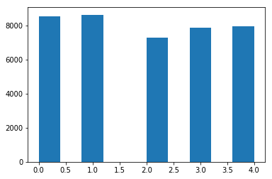

```python
plt.hist(df_cleaned['WAGP_CAT'])
```

```python
# Make sure label columns is the first column, and drop WAGP (will make problem trivial otherwise)
# XGBoost expects labels to be in the first column

# YOUR CODE HERE
df_cleaned2 = df_cleaned.drop(['WAGP'], axis=1)[['WAGP_CAT', 'JWMNP', 'JWTR', 'MAR', 'PERNP', 'NWAV',
                                               'NWLA', 'NWLK', 'NWAB', 'SCHL', 'WKW', 'FOD1P']]
```

### 2.d) Save preprocessed data to s3

This step is needed for using XGBoost with Amazon Sagemaker. We have provided this code for you, but you should look through them to see what they do.

Expected outputs: None

```python
# shuffle data and train/val/test split, at 6:2:2

import numpy as np

x_train_df, x_val_df, x_test_df = \
    np.split(df_cleaned2.sample(frac=1, random_state=1729),
             [int(0.6 * len(df_cleaned2)), int(0.8*len(df_cleaned2))])

x_train = x_train_df.values
x_val = x_val_df.values
x_test = x_test_df.values[:,1:]  # remove the label column
```

```python
# save preprocessed data to s3 for XGBoost to access

bucket = "mgta495-hw3"
prefix = "data"

datasets = [('train', x_train), ('val', x_val), ('test', x_test)]  # Note: also using val as test
data_locations = []
for key, x in datasets:
    file = "{}/{}_data/data.csv".format(prefix,key)
    location = "s3://{}/{}".format(bucket, file); data_locations += [location]
    print('{} data will be uploaded to: {}'.format(key, location))
    np.savetxt("{}.csv".format(key), x, delimiter=',')
    boto3.Session().resource('s3').Bucket(bucket).Object(file).upload_file("{}.csv".format(key))
```

```
train data will be uploaded to: s3://mgta495-hw3/data/train_data/data.csv
val data will be uploaded to: s3://mgta495-hw3/data/val_data/data.csv
test data will be uploaded to: s3://mgta495-hw3/data/test_data/data.csv
```

```python
# set model output location

output_location = "s3://{}/{}/output".format(bucket,prefix)
print('training artifacts will be uploaded to: {}'.format(output_location))
```

```
training artifacts will be uploaded to: s3://mgta495-hw3/data/output
```

## 3) Train a XGBoost model with static hyperparameters

### 3.1) Train the model

Call the Amazon Sagemaker API to spawn a training container for XGBoost. Observe the logs.

Your task:

1. Run the following cells.

Expected output:

1. Logs from the XGBoost container showing that training has completed
   - you will start to get logs in this notebook after calling Estimater.fit()

```python
# create input channels to stream data
# NOTE: in the case of using CSV files, all data is saved to the worker containers before training starts;
#       only libsvm supports real data streaming

train_channel = sagemaker.inputs.s3_input(data_locations[0], content_type='text/csv')
val_channel = sagemaker.inputs.s3_input(data_locations[1], content_type='text/csv')

data_channels = {'train': train_channel, 'validation': val_channel}
```

```python
# create the estimator instance

from sagemaker.amazon.amazon_estimator import get_image_uri
training_image = get_image_uri(boto3.Session().region_name, 'xgboost', '0.90-1')
smclient = boto3.Session().client('sagemaker')

xgb_model = sagemaker.estimator.Estimator(training_image,
                                          iam_role,
                                          train_instance_count=1,
                                          train_instance_type='ml.m5.xlarge',
                                          train_volume_size = 5,
                                          output_path=output_location,
                                          sagemaker_session=sagemaker.Session())
```

```python
# set estimator hyperparameters, these will be passed to the XGBoost container

xgb_model.set_hyperparameters(max_depth = 5,
                              eta = .2,
                              gamma = 4,
                              min_child_weight = 6,
                              objective = "multi:softmax",
                              num_class = 5,
                              num_round = 10)
```

```python
# fit using the data channels

xgb_model.fit(data_channels)
```

[output not shown]

```python
# print the model's S3 URL
xgb_model.model_data
```

```
's3://mgta495-hw3/data/output/sagemaker-xgboost-2020-03-10-04-59-47-250/output/model.tar.gz'
```

### 3.2) Getting a transformer for batch inferencing

A Transformer spawns a Batch-Transform job using a trained model, and predicts labels for pre-uploaded data on S3. This is mainly for when we have a large amount of data to run inference on, and don't need to get results back in real time.

To see the Batch-Transform job you have started, go to the SageMaker console's Batch Transform Jobs page, under the Inference menu on the left. Click into the Job to see its details. There is a link to the output S3 location at the bottom of the Job details page, which you can use to retrieve the output file containing predicted labels.

Expected output: None, but submit a screenshot of the completed batch transform job

```python
test_output_location = output_location+"/results"
print('test outputs will be uploaded to: {}'.format(test_output_location))
```

```
test outputs will be uploaded to: s3://mgta495-hw3/data/output/results
```

```python
xgb_transformer = xgb_model.transformer(instance_count=1,
                                        instance_type='ml.m5.xlarge',
                                        output_path=test_output_location)
```

```python
xgb_transformer.transform(data_locations[2],
                          content_type="text/csv")
```

### 3.3) Deploy model for interactive inference

Real Time Predictors are live services run on Amazon servers, which accepts streamed data (i.e. from live sensors or user input) and uses a trained model to make predictions in real time, hence the name. These predictors are backed by an entire stack of different services and networks, and thus takes some time to startup.

Since the predictors work only with byte streams and not standard python objects, we have written a simple utility that takes care of data processing for you. The process is not that complicated, so feel free to experiment with the predictor interface yourself.

After obtaining the predicted labels from the real time predictor, use the confusion_matrix and classification_report methods from sklearn.metrics to show the model's classification performance.

Your tasks:

1. Spawn a Real Time Predictor using Estimator.deploy()
2. Run real time inference for the first 1000 points in `test.csv`

Expected output:

1. Confusion matrix and classification report, using results from the first 1000 data points in the test set
2. Also submit a screenshot of the deleted Endpoint in SageMaker console (the list should be empty)

```python
def predict_file(input_path, predictor, limit=1000):
    """
    Utility for piping a local test file to Sagemaker's Real Time Predictor interface
    Returns a numpy array of integers as the predicted labels

    input_path: path to the input CSV file. This should be a local file, you can use "test.csv"
    predictor: the predictor object we created for you
    limit: the max number of data points to send to the predictor. We have set this to 1000 for you.
    """
    res = []
    with open(input_path, 'r') as f:
        lines = f.readlines()
    for i, l in enumerate(lines):
        res += [predictor.predict(l)]
        print("Progress: {}/{}".format(i, len(lines)), end='\r')
        if limit is not None and i >= limit-1:
            break
    y_pred = np.array([float(e.decode('utf-8')) for e in res]).astype(int)
    return y_pred
```

```python
# Deploy the real time predictor on Amazon servers. This will take several minutes.
xgb_predictor = xgb_model.deploy(initial_instance_count=1,
                                 content_type='text/csv',
                                 instance_type='ml.t2.xlarge')
```

```
Using already existing model: sagemaker-xgboost-2020-03-10-04-59-47-250
```

```
-----------------!
```

```python
# run inference and get reports
# NOTE: XGBoost's RealTimePredictor accepts only strings in CSV format.

from sklearn.metrics import confusion_matrix, classification_report

# Hint: Use the predict_file() method we have provided

preds = predict_file("test.csv",
                     xgb_predictor)
```

```
Progress: 999/8056
```

```python
conf = confusion_matrix(x_test_df['WAGP_CAT'].iloc[:1000], preds)
conf
```

```
array([[189,  12,   7,   5,   3],
       [  0, 221,   1,   0,   0],
       [  0,   0, 175,   6,   0],
       [  1,   0,   1, 187,   4],
       [  1,   0,   0,   0, 187]])
```

```python
report = classification_report(x_test_df['WAGP_CAT'].iloc[:1000], preds, output_dict=True, target_names=[0, 1, 2, 3, 4])
report
```

```
{0: {'precision': 0.9895287958115183,
  'recall': 0.875,
  'f1-score': 0.9287469287469288,
  'support': 216},
 1: {'precision': 0.9484978540772532,
  'recall': 0.9954954954954955,
  'f1-score': 0.9714285714285714,
  'support': 222},
 2: {'precision': 0.9510869565217391,
  'recall': 0.9668508287292817,
  'f1-score': 0.958904109589041,
  'support': 181},
 3: {'precision': 0.9444444444444444,
  'recall': 0.9689119170984456,
  'f1-score': 0.9565217391304347,
  'support': 193},
 4: {'precision': 0.9639175257731959,
  'recall': 0.9946808510638298,
  'f1-score': 0.9790575916230367,
  'support': 188},
 'micro avg': {'precision': 0.959,
  'recall': 0.959,
  'f1-score': 0.959,
  'support': 1000},
 'macro avg': {'precision': 0.9594951153256301,
  'recall': 0.9601878184774104,
  'f1-score': 0.9589317881036024,
  'support': 1000},
 'weighted avg': {'precision': 0.9599457552540114,
  'recall': 0.959,
  'f1-score': 0.9584996461794008,
  'support': 1000}}
```

```python
# delete the endpoint after inference to save cost; you may also delete the model.
# xgb_predictor.delete_endpoint()
xgb_predictor.delete_model()
```

## 4) (Optional) Hyperparameter tuning

The above static XGBoost hyperparameters are not optimal for this dataset. Use Sagemaker's Automatic Hyperparameter Tuning functionality to find the best set of hyperparameters and the resulting model.

### 4.1) Start a Hyperparameter Tuning Job

Use the sample tuning configurations to launch a hyperparameter tuning job.

For this assignment, try to adjust the continuous hyperparameter min_child_weight in the range [1,10], and the integer hyperparameter max_depth in the range [1,10].

Your task:

1. Fill in the missing configurations for the two hyperparameters to tune in `tuning_job_config`
2. Start the hyperparameter tuning job

Expected output: None, but include a screenshot in the report to show your completed tuning job.

```python
# You need to change the job name every time.
# Amazon likely uses job logs to bill users, so jobs cannot be deleted or overwritten.
tuning_job_name = "MyTuningJob8"

# tuning configs: parameter ranges
tuning_job_config = {
    "ParameterRanges": {
      "CategoricalParameterRanges": [],
      "ContinuousParameterRanges": [
        {
            "MaxValue": "1",
            "MinValue": "0",
            "Name": "eta"
        },
        {
            "MaxValue": "10",
            "MinValue": "1",
            "Name": "min_child_weight"
        }

      ],
      "IntegerParameterRanges": [
        {
            "MaxValue": "10",
            "MinValue": "1",
            "Name": "max_depth"
        }
      ]
    },
    "ResourceLimits": {
      "MaxNumberOfTrainingJobs": 10,    # Set the number of iterations here
      "MaxParallelTrainingJobs": 2      # Set the max concurrent training jobs
    },
    "Strategy": "Bayesian",
    "HyperParameterTuningJobObjective": {
      "MetricName": "validation:f1",
      "Type": "Maximize"
    }
  }

# Training job definition: data sources, instance config, static hyperparams
training_job_definition = {
    "AlgorithmSpecification": {
      "TrainingImage": training_image,
      "TrainingInputMode": "File"
    },
    "InputDataConfig": [
      {
        "ChannelName": "train",
        "CompressionType": "None",
        "ContentType": "csv",
        "DataSource": {
          "S3DataSource": {
            "S3DataDistributionType": "FullyReplicated",
            "S3DataType": "S3Prefix",
            "S3Uri": data_locations[0]
          }
        }
      },
      {
        "ChannelName": "validation",
        "CompressionType": "None",
        "ContentType": "csv",
        "DataSource": {
          "S3DataSource": {
            "S3DataDistributionType": "FullyReplicated",
            "S3DataType": "S3Prefix",
            "S3Uri": data_locations[1]
          }
        }
      }
    ],
    "OutputDataConfig": {
      "S3OutputPath": output_location
    },
    "ResourceConfig": {
      "InstanceCount": 2,
      "InstanceType": "ml.c4.2xlarge",
      "VolumeSizeInGB": 10
    },
    "RoleArn": iam_role,
    "StaticHyperParameters": {        # Set static hyperparameters here, these won't be tuned
      "gamma": "4",
      "objective": "multi:softmax",
      "num_class": "5",
      "num_round": "10"
    },
    "StoppingCondition": {
      "MaxRuntimeInSeconds": 3600
    }
}
```

```python
# create hyperparam tuning job
smclient.create_hyper_parameter_tuning_job(HyperParameterTuningJobName = tuning_job_name,
                                           HyperParameterTuningJobConfig = tuning_job_config,
                                           TrainingJobDefinition = training_job_definition)
```

```
{'HyperParameterTuningJobArn': 'arn:aws:sagemaker:us-west-2:085093115427:hyper-parameter-tuning-job/mytuningjob8',
 'ResponseMetadata': {'RequestId': '32a6bd7c-2fdb-42e6-96f4-d0f7f17803f2',
  'HTTPStatusCode': 200,
  'HTTPHeaders': {'x-amzn-requestid': '32a6bd7c-2fdb-42e6-96f4-d0f7f17803f2',
   'content-type': 'application/x-amz-json-1.1',
   'content-length': '113',
   'date': 'Tue, 10 Mar 2020 04:28:44 GMT'},
  'RetryAttempts': 0}}
```

### 4.2) Rerun validation to examine model performance

After the hyperparameter tuning job is complete, find the URL of the model file of your best performing model, by:

1. Go to the Hyperparameter tuning jobs page on SageMaker console
2. Select Best Training Job, and go to the job's details page
3. Scroll to the bottom of the page, there is a URL to the saved model file (ending with `.tar.gz`).

Copy this URL as `model_location_s3`, run below cells, and report model performance in the same way as **3.3)**

```python
from sagemaker.model import Model

model_location_s3 = "s3://mgta495-hw3/data/output/MyTuningJob8-005-0a43e688/output/model.tar.gz"  # S3 Path to your model artifact

tuned_model = Model(model_location_s3,
                    image=training_image,
                    role=iam_role,
                    sagemaker_session=sm_session
                   )
tuned_model.deploy(initial_instance_count=1,
                   instance_type='ml.m4.xlarge',
                  )
```

```
-----------------!
```

```python
from sagemaker.predictor import RealTimePredictor
tuned_predictor = RealTimePredictor(tuned_model.endpoint_name,
                                    sm_session,
                                    content_type='text/csv')
```

```python
# run inference and get reports
# NOTE: XGBoost's RealTimePredictor accepts only strings in CSV format.

from sklearn.metrics import confusion_matrix, classification_report

# YOUR CODE HERE

preds = predict_file("test.csv",
                     tuned_predictor)

conf1 = confusion_matrix(x_test_df['WAGP_CAT'].iloc[:1000], preds)
conf1
```

```
Progress: 999/8056
```

```
array([[190,  11,   7,   5,   3],
       [  0, 221,   1,   0,   0],
       [  0,   0, 176,   5,   0],
       [  1,   0,   5, 184,   3],
       [  2,   0,   0,  19, 167]])
```

```python
report1 = classification_report(x_test_df['WAGP_CAT'].iloc[:1000], preds, output_dict=True, target_names=[0, 1, 2, 3, 4])
report1
```

```
{0: {'precision': 0.9844559585492227,
  'recall': 0.8796296296296297,
  'f1-score': 0.9290953545232273,
  'support': 216},
 1: {'precision': 0.9525862068965517,
  'recall': 0.9954954954954955,
  'f1-score': 0.9735682819383259,
  'support': 222},
 2: {'precision': 0.9312169312169312,
  'recall': 0.9723756906077348,
  'f1-score': 0.9513513513513513,
  'support': 181},
 3: {'precision': 0.863849765258216,
  'recall': 0.9533678756476683,
  'f1-score': 0.9064039408866996,
  'support': 193},
 4: {'precision': 0.9653179190751445,
  'recall': 0.8882978723404256,
  'f1-score': 0.925207756232687,
  'support': 188},
 'micro avg': {'precision': 0.938,
  'recall': 0.938,
  'f1-score': 0.938,
  'support': 1000},
 'macro avg': {'precision': 0.9394853561992133,
  'recall': 0.9378333127441907,
  'f1-score': 0.9371253369864583,
  'support': 1000},
 'weighted avg': {'precision': 0.9408696630088939,
  'recall': 0.938,
  'f1-score': 0.9378863685247982,
  'support': 1000}}
```

```python
# delete model and endpoint after inference to save cost

tuned_predictor.delete_endpoint()
tuned_predictor.delete_model()
```